# Lab 2. Monarch Populations

2026-02-12

# Introduction

The goal of this lab is to study temporal trends in the western populations of the monarch butterfly (*Danaus plexippus plexippus*). Although this is the iconic butterfly species – even featured as the default butterfly emoji on Android phones – the migratory subspecies is classified as vulnerable by the International Union for the Conservation of Nature (IUCN). We’ll investigate the abundances of western monarch butterflies in their overwintering areas on the coast of central and southern California, where the adult super-generation spends 4-5 months.

We’ll measure some metrics of monarch ecology based on their population size at time $t$ ($N_t$). Specifically, we will calculate the finite population growth rate ($\lambda$), the change in population size over time ($\Delta N/\Delta t$), and the change in finite population growth rate over time ($\Delta\lambda/\Delta t$). These quantities can be calculated with the following equations:

$\lambda_{t} = N_{t+1}/N_t$

$\frac{\Delta N}{\Delta t} = \frac{N_t-N_{t-1}}{t_2-t_1}$

$\frac{\Delta\lambda}{\Delta t} = \frac{\lambda_t-\lambda_{t-1}}{t_2-t_1}$

The magnitude of lambda indicates how the population is changing:

- population growth when $\lambda > 1$
- population stability when $\lambda = 1$
- population decline when $\lambda < 1$

The other two formulas have equilibrium values of $\frac{\Delta N}{\Delta t} = 0$ and $\frac{\Delta\lambda}{\Delta t} = 0$.

# Data Inputting, Cleaning, and Formatting

Read in the csv file on monarch butterfly populations and store it as a data frame.

```r
monarchs <- read.csv("Western Monarch Counts 2025.csv")
options(scipen = 999)
```

Look at the dataset to get a sense of how it’s formatted. What do the rows and columns show? Are the columns named appropriately?

```r
str(monarchs)
```

```
## 'data.frame':    387 obs. of  43 variables:
##  $ SITE.ID         : int  3120 3118 3119 3122 3121 3133 3138 3235 3195 3125 ...
##  $ SITE.NAME       : chr  "Anchor Bay" "China Gulch, Gualala" "Fish Rock #1, Anchor Bay" "Bay Flat Rd., Bodega Bay" ...
##  $ COUNTY.or.REGION: chr  "Mendocino" "Mendocino" "Mendocino" "Sonoma" ...
##  $ X1997           : int  1310 2000 NA NA NA 440 6220 NA NA NA ...
##  $ X1998           : int  NA 0 50 NA NA 1600 NA NA NA NA ...
##  $ X1999           : int  0 0 0 450 300 0 0 NA NA NA ...
##  $ X2000           : int  NA NA NA 700 2500 NA 6 NA NA NA ...
##  $ X2001           : int  NA NA NA 3 4 NA 0 NA NA NA ...
##  $ X2002           : int  NA NA NA NA NA NA NA NA NA NA ...
##  $ X2003           : int  NA NA NA NA 160 NA NA NA NA NA ...
##  $ X2004           : int  NA NA NA NA 34 NA NA NA NA NA ...
##  $ X2005           : int  NA NA 0 NA 0 0 NA NA NA NA ...
##  $ X2006           : int  NA NA NA NA 0 NA NA NA NA NA ...
##  $ X2007           : int  NA NA NA NA 0 NA NA NA NA NA ...
```

[output cut: 29 more lines]

The dataset is currently in wide format, but to analyze it, we need to convert it to long format. Use the function `pivot_longer()` from `tidyr` to accomplish this. Make two new columns, one for the abundance “Count” and one for the time at which the abundance was measured “Count_time”.

```r
library(tidyr)
monarchs_long <- pivot_longer(monarchs,
                              cols = "X1997":"X2025",
                              values_to = "Count",
                              names_to = "Count_time")
```

Check the object class of your new Count_time column. What kind of variable is it?

```r
class(monarchs_long$Count_time)
```

```
## [1] "character"
```

We want to calculate several population ecology metrics for the monarchs, so we need to convert Count_time from a character to a numeric variable. This will require several steps. First, look at the different values contained in count time.

```r
unique(monarchs_long$Count_time)
```

```
##  [1] "X1997"        "X1998"        "X1999"        "X2000"        "X2001"
##  [6] "X2002"        "X2003"        "X2004"        "X2005"        "X2006"
## [11] "X2007"        "X2008"        "X2009"        "X2010"        "X2011"
## [16] "X2012"        "X2013"        "X2014"        "X2015"        "X2016"
## [21] "LS.2016.17"   "X2017"        "LS.2017.2018" "X2018"        "LS.2018.2019"
## [26] "X2019"        "LS.2019.2020" "X2020"        "LS.2020.2021" "X2021"
## [31] "LS.2021.2022" "X2022"        "LS.2022.2023" "X2023"        "LS.2023.2024"
## [36] "ES.2024"      "X2024"        "LS.2024.2025" "ES.2025"      "X2025"
```

Notice how these values begin with one of the following:

- “ES” for early season counts, usually around Halloween (Oct. 31)
- “X” for peak season counts, usually around Thanksgiving (use Nov. 25)
- “LS” for late season counts, usually around New Years Eve (Dec. 31)

Let’s create a new fractional year variable for each of these prefixes using the `yday()` function in the `lubridate` library. Use the dates given above as a fraction of the number of days in a year. Round the values of these variables to three decimal places.

```r
library(lubridate)
ESday <- round(yday("2023-10-31")/365, 3)
Xday <- round(yday("2023-11-25")/365, 3)
LSday <- round(yday("2023-12-31")/365, 3)
```

Now add to your long format data frame a new column that converts Count_time to a decimal year. Some useful functions are `str_starts()` and `str_remove()` from the `stringr` package, `mutate()` and `case_when()` from `dplyr`.

```r
library(dplyr)
library(stringr)

monarchs_long <- monarchs_long %>%
  mutate(Year = case_when(
    str_starts(Count_time, "ES") ~ as.numeric(str_remove(Count_time, "ES.")) +
      ESday,
    str_starts(Count_time, "X") ~ as.numeric(str_remove(Count_time, "X")) +
      Xday,
    str_starts(Count_time, "LS") ~ as.numeric(str_extract(Count_time, "\\d{4}")) +
      LSday
  ))
```

Double-check that your decimal years make sense using the `table()` function.

```r
table(monarchs_long$Count_time, monarchs_long$Year)
```

```
##
##                1997.901 1998.901 1999.901 2000.901 2001.901 2002.901 2003.901
##   ES.2024             0        0        0        0        0        0        0
##   ES.2025             0        0        0        0        0        0        0
##   LS.2016.17          0        0        0        0        0        0        0
##   LS.2017.2018        0        0        0        0        0        0        0
##   LS.2018.2019        0        0        0        0        0        0        0
##   LS.2019.2020        0        0        0        0        0        0        0
##   LS.2020.2021        0        0        0        0        0        0        0
##   LS.2021.2022        0        0        0        0        0        0        0
##   LS.2022.2023        0        0        0        0        0        0        0
##   LS.2023.2024        0        0        0        0        0        0        0
##   LS.2024.2025        0        0        0        0        0        0        0
##   X1997             387        0        0        0        0        0        0
##   X1998               0      387        0        0        0        0        0
##   X1999               0        0      387        0        0        0        0
##   X2000               0        0        0      387        0        0        0
##   X2001               0        0        0        0      387        0        0
##   X2002               0        0        0        0        0      387        0
##   X2003               0        0        0        0        0        0      387
##   X2004               0        0        0        0        0        0        0
##   X2005               0        0        0        0        0        0        0
##   X2006               0        0        0        0        0        0        0
##   X2007               0        0        0        0        0        0        0
##   X2008               0        0        0        0        0        0        0
##   X2009               0        0        0        0        0        0        0
##   X2010               0        0        0        0        0        0        0
##   X2011               0        0        0        0        0        0        0
##   X2012               0        0        0        0        0        0        0
##   X2013               0        0        0        0        0        0        0
##   X2014               0        0        0        0        0        0        0
##   X2015               0        0        0        0        0        0        0
##   X2016               0        0        0        0        0        0        0
##   X2017               0        0        0        0        0        0        0
##   X2018               0        0        0        0        0        0        0
##   X2019               0        0        0        0        0        0        0
##   X2020               0        0        0        0        0        0        0
##   X2021               0        0        0        0        0        0        0
##   X2022               0        0        0        0        0        0        0
##   X2023               0        0        0        0        0        0        0
```

[output cut: 197 more lines]

```
##   X2011               0
##   X2012               0
##   X2013               0
##   X2014               0
##   X2015               0
##   X2016               0
##   X2017               0
##   X2018               0
##   X2019               0
##   X2020               0
##   X2021               0
##   X2022               0
##   X2023               0
##   X2024               0
##   X2025             387
```

Although we went through the trouble of accounting for early and late season counts, these were not consistently recorded. Therefore, it’s best to remove these rows using `filter()`.

```r
monarchs_final <- filter(monarchs_long, str_starts(Count_time, "X"))
```

Now we can calculate the second metric, population growth rate ($\lambda$)! It’s important to ensure that we’re calculating separate rates per site and with consecutive years, so you’ll want to use the `arrange()` and `group_by()` functions from `dplyr`. We also want to compare apples to apples, so only use the peak season counts beginning with “X” (see step above). The `lead()` function is super handy here. It’s also a good idea to replace any divide by zero errors (`Inf`) or 0/0 errors (`NaN`) with 0.

```r
monarchs_final <- monarchs_final %>%
  arrange(Year) %>%
  group_by(SITE.NAME) %>%
  mutate(lambda = lead(Count)/Count,
         lambda = if_else(is.infinite(lambda), 0,
                          if_else(is.nan(lambda), 0, lambda)))
```

Just two more population metrics to calculate: $\Delta N/\Delta t$ and $\Delta\lambda/\Delta t$. Remember to calculate these for each site separately. The function `lag()` is useful here.

```r
monarchs_final <- monarchs_final %>%
  arrange(Year) %>%
  group_by(SITE.NAME) %>%
  mutate(dNdt = (Count-lag(Count))/(Year-lag(Year)),
         dldt = (lambda-lag(lambda))/(Year-lag(Year)))
```

# Data Visualization

Now that we have our four population ecology metrics, let’s make some graphs!

First, we’ll create a time series plot with `ggplot2` that shows the mean population size per year ($N_t$) across all sites and per region.

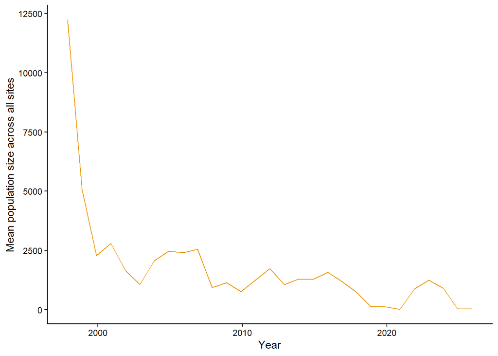

```r
library(ggplot2)

ggplot(data = monarchs_final, aes(x = Year)) +
  stat_summary(aes(y = Count), fun = "mean", geom = "line", color = "orange2") +
  scale_y_continuous(name = "Mean population size across all sites") +
  theme_classic()
```

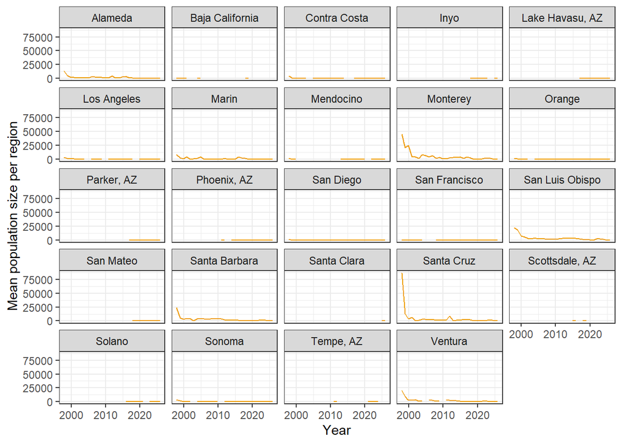

```r
monarchs_final %>%
  group_by(COUNTY.or.REGION, Year) %>%
  summarize(meanCount = mean(Count, na.rm = TRUE)) %>%
  ggplot(aes(x = Year, y = meanCount)) +
  geom_line(color = "orange2") +
  scale_y_continuous(name = "Mean population size per region") +
  theme_bw() +
  facet_wrap(~COUNTY.or.REGION)
```

Second, modify the code above to create a time series plot that shows the mean finite rate of increase ($\lambda$) across all sites and per region. Add the equilibrium value of stable population growth as a horizontal line.

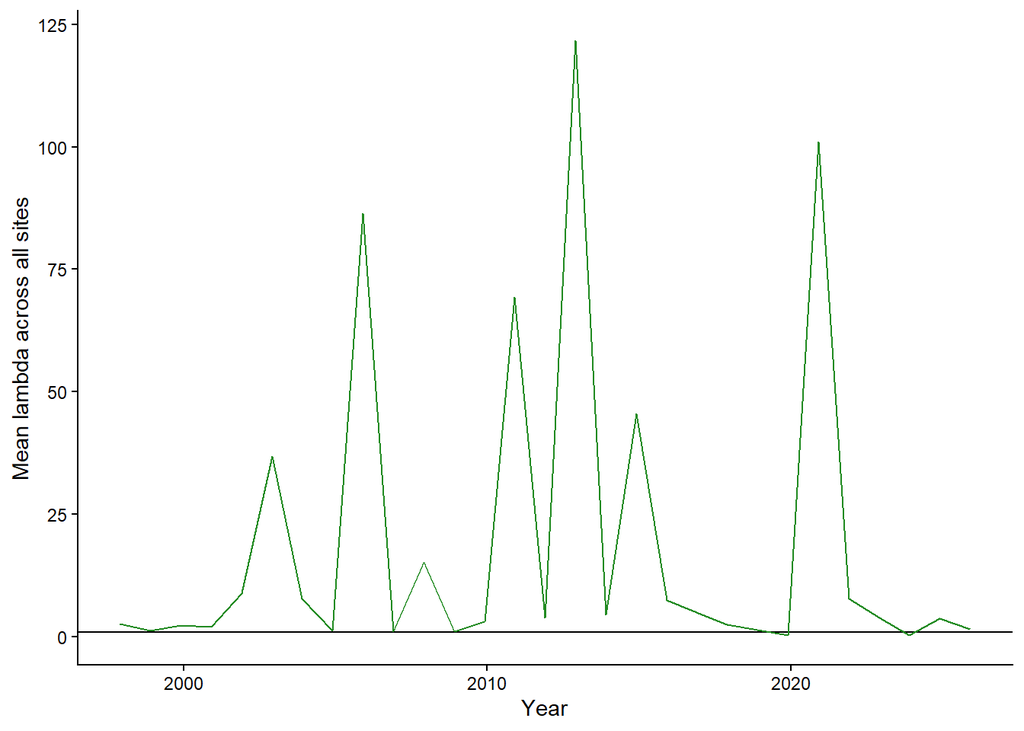

```r
ggplot(data = monarchs_final, aes(x = Year)) +
  geom_hline(yintercept = 1) +
  stat_summary(aes(y = lambda), fun = "mean", geom = "line", color = "forestgreen") +
  scale_y_continuous(name = "Mean lambda across all sites") +
  theme_classic()
```

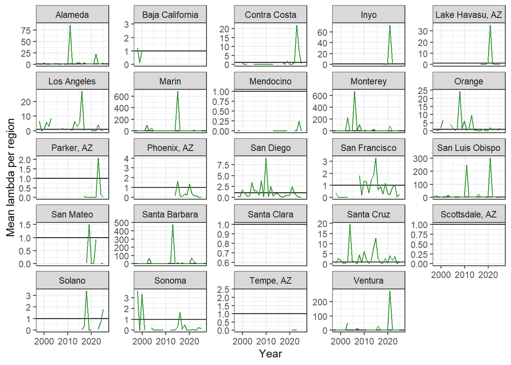

```r
monarchs_final %>%
  group_by(COUNTY.or.REGION, Year) %>%
  summarize(meanlambda = mean(lambda, na.rm = TRUE)) %>%
  ggplot(aes(x = Year, y = meanlambda)) +
  geom_hline(yintercept = 1) +
  geom_line(color = "forestgreen") +
  scale_y_continuous(name = "Mean lambda per region") +
  theme_bw() +
  facet_wrap(~COUNTY.or.REGION, scales = "free_y")
```

Third, modify this code to create a time series plot that shows the mean change in population size over time ($\Delta N/\Delta t$) across all sites and per region. Add the equilibrium value of stable population growth as a horizontal line.

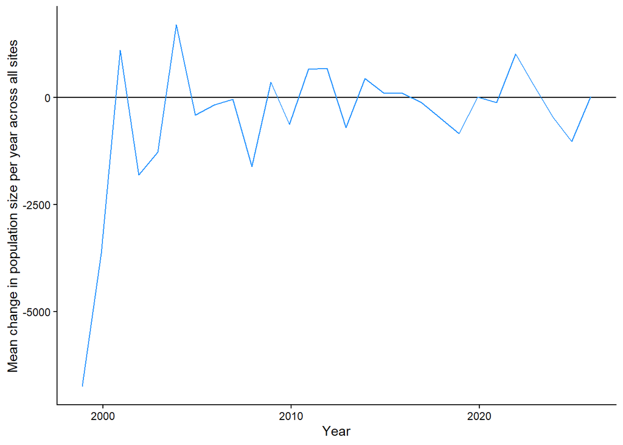

```r
ggplot(data = monarchs_final, aes(x = Year)) +
  geom_hline(yintercept = 0) +
  stat_summary(aes(y = dNdt), fun = "mean", geom = "line", color = "dodgerblue") +
  scale_y_continuous(name = "Mean change in population size per year across all sites") +
  theme_classic()
```

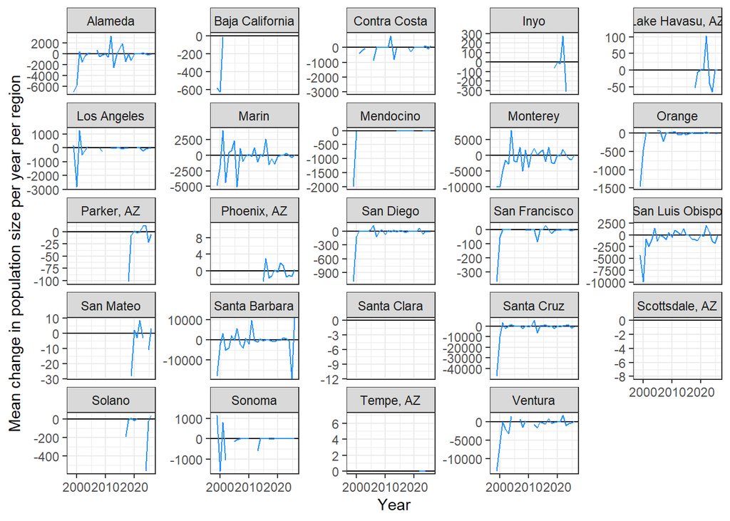

```r
monarchs_final %>%
  group_by(COUNTY.or.REGION, Year) %>%
  summarize(meandNdt = mean(dNdt, na.rm = TRUE)) %>%
  ggplot(aes(x = Year, y = meandNdt)) +
  geom_hline(yintercept = 0) +
  geom_line(color = "dodgerblue") +
  scale_y_continuous(name = "Mean change in population size per year per region") +
  theme_bw() +
  facet_wrap(~COUNTY.or.REGION, scales = "free_y")
```

Fourth, modify this code to create a time series plot that shows the mean change in finite population growth rate over time ($\Delta\lambda/\Delta t$) across all sites and per region. Add the equilibrium value of stable population growth as a horizontal line.

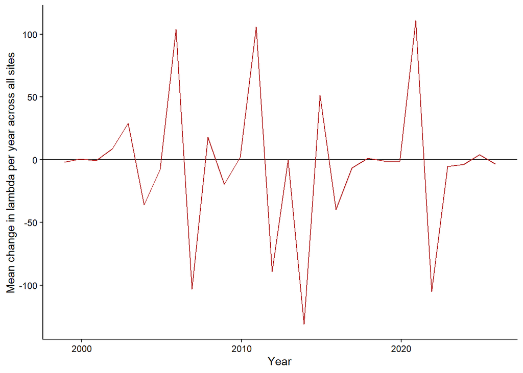

```r
ggplot(data = monarchs_final, aes(x = Year)) +
  geom_hline(yintercept = 0) +
  stat_summary(aes(y = dldt), fun = "mean", geom = "line", color = "firebrick") +
  scale_y_continuous(name = "Mean change in lambda per year across all sites") +
  theme_classic()
```

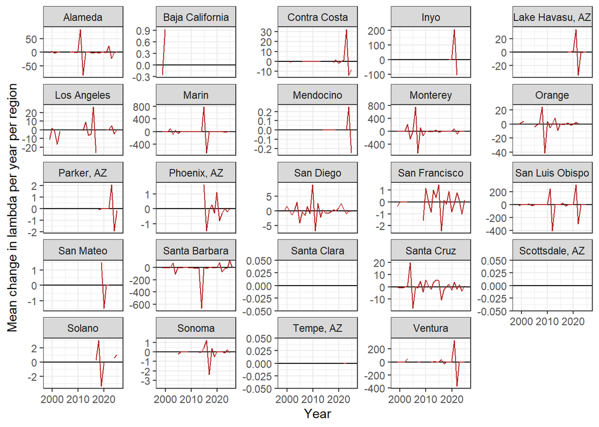

```r
monarchs_final %>%
  group_by(COUNTY.or.REGION, Year) %>%
  summarize(meandldt = mean(dldt, na.rm = TRUE)) %>%
  ggplot(aes(x = Year, y = meandldt)) +
  geom_hline(yintercept = 0) +
  geom_line(color = "firebrick") +
  scale_y_continuous(name = "Mean change in lambda per year per region") +
  theme_bw() +
  facet_wrap(~COUNTY.or.REGION, scales = "free_y")
```

What’s going on here? If monarch butterfly populations are declining throughout their overwintering range, then why are so many *mean* $\lambda$ values greater than 1 or *mean* $\Delta\lambda/\Delta t$ values greater than 0? Think about what other summary statistics and/or population growth metrics may be more informative and make a different kind of plot.

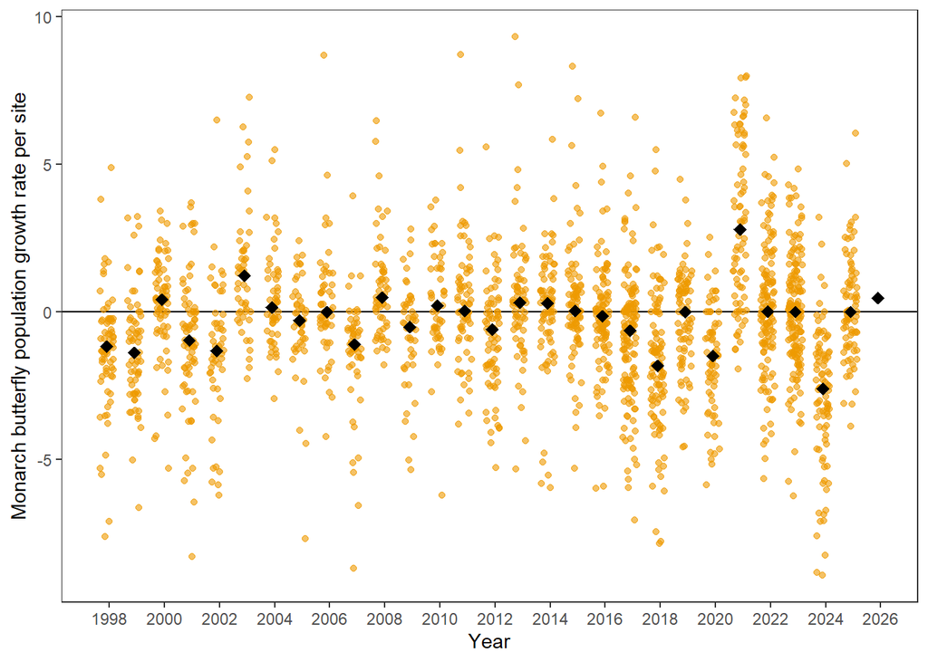

```r
ggplot(data = filter(monarchs_final, lambda > 0),
       aes(x = Year, y = log(lambda))) + #log-transforming lambda to yield r
  geom_hline(yintercept = 0) +
  geom_jitter(width = 0.25, color = "orange2", alpha = 0.6) +
  stat_summary(fun = "median", geom = "point", shape = 18, size = 3) +
  scale_y_continuous(name = "Monarch butterfly population growth rate per site") +
  scale_x_continuous(breaks = seq(1990,2026,2)) +
  theme_test()
```

Now that we have a sense of the overall population trends, let’s zoom in to a single site where there are no missing data: Natural Bridges State Beach, Santa Cruz, CA (ID 2998). Create four plots, one for each of the population growth metrics as above.

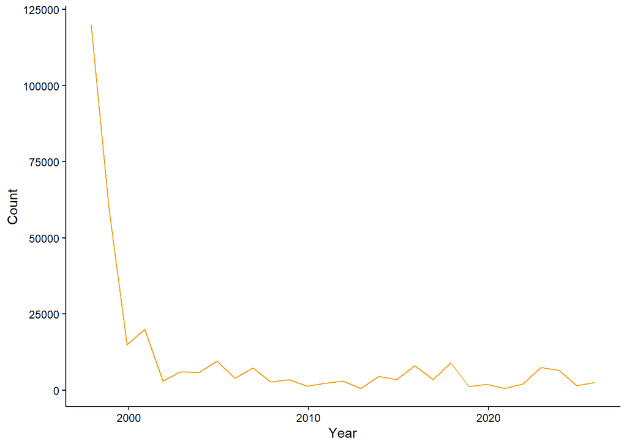

```r
NBSB <- filter(monarchs_final, SITE.ID == 2998)

ggplot(data = NBSB, aes(x = Year)) +
  geom_line(aes(y = Count), color = "orange2") +
  theme_classic()
```

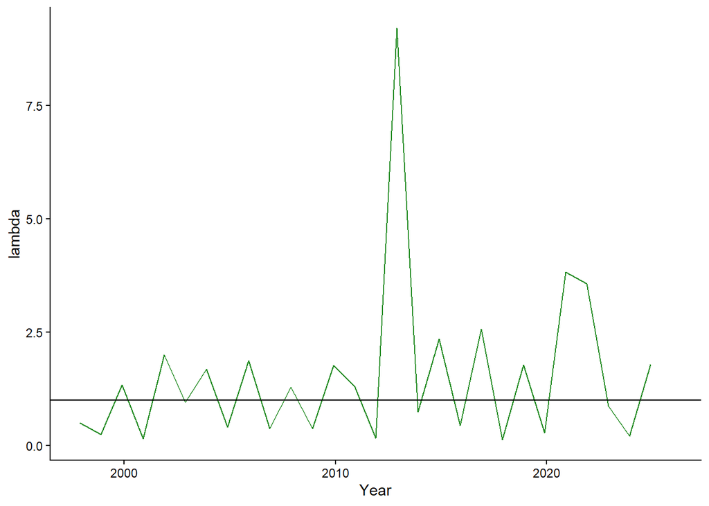

```r
ggplot(data = NBSB, aes(x = Year)) +
  geom_line(aes(y = lambda), color = "forestgreen") +
  geom_hline(yintercept = 1) +
  theme_classic()
```

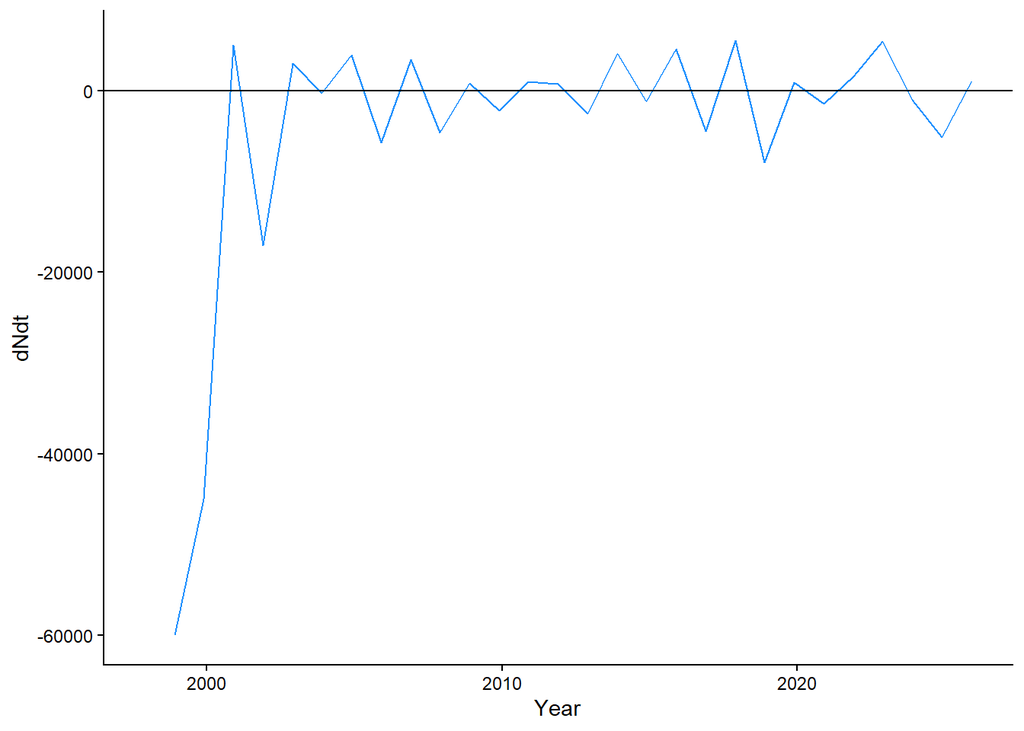

```r
ggplot(data = NBSB, aes(x = Year)) +
  geom_line(aes(y = dNdt), color = "dodgerblue") +
  geom_hline(yintercept = 0) +
  theme_classic()
```

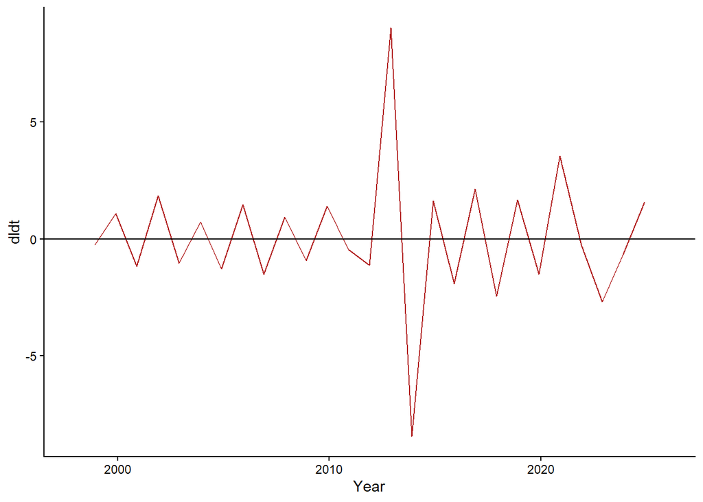

```r
ggplot(data = NBSB, aes(x = Year)) +
  geom_line(aes(y = dldt), color = "firebrick") +
  geom_hline(yintercept = 0) +
  theme_classic()
```

In your discussion, reflect on the trends in the four population growth metrics across all of coastal California, within different regions, and at Natural Bridges State Beach. Place your findings into context from the readings we discussed this week and other sources that you find.